# ggplot2 ecosystem & designing visualizations

## Use color to draw attention

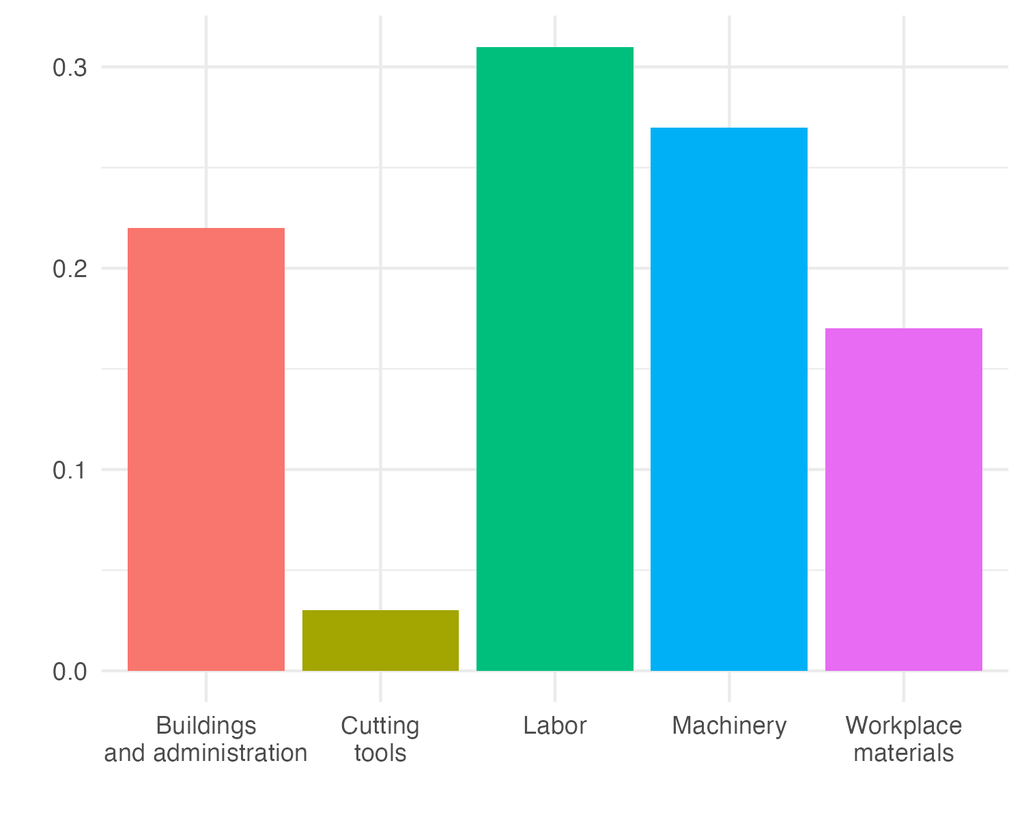

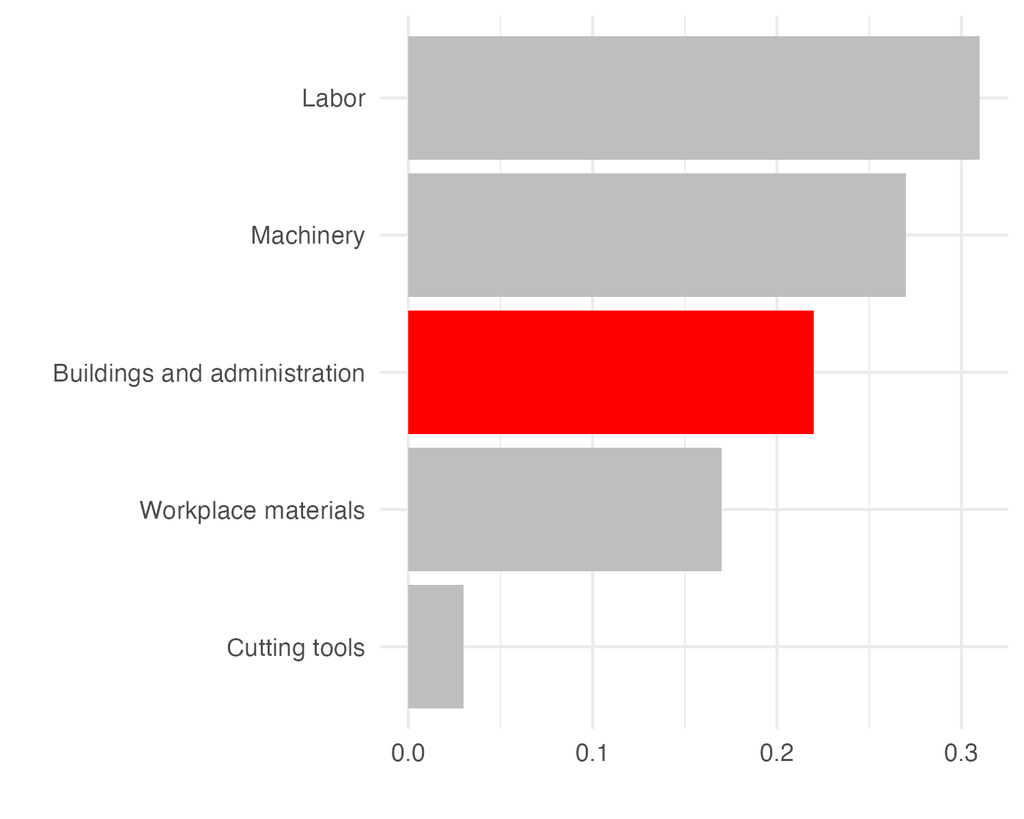

## Tell a story

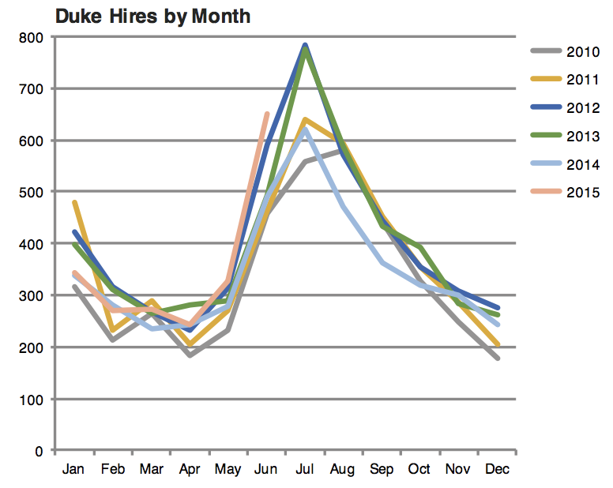

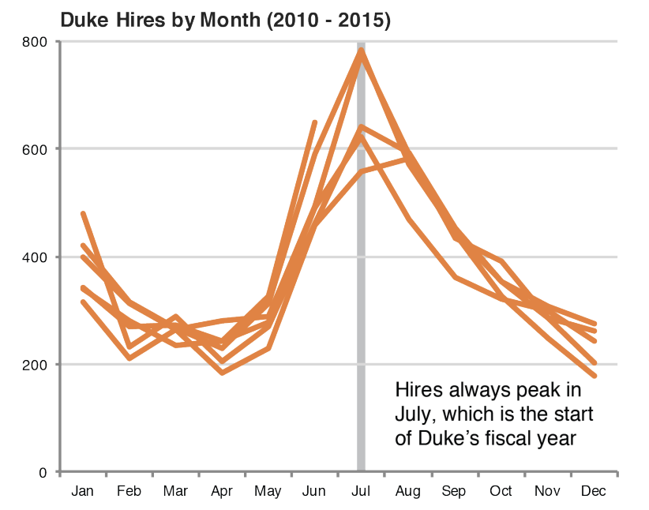

*Credit*: Angela Zoss and Eric Monson, Duke DVS

## Leave out non-story details

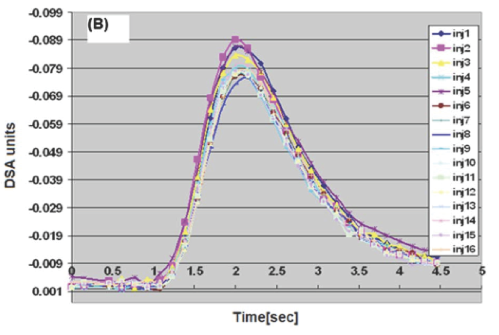

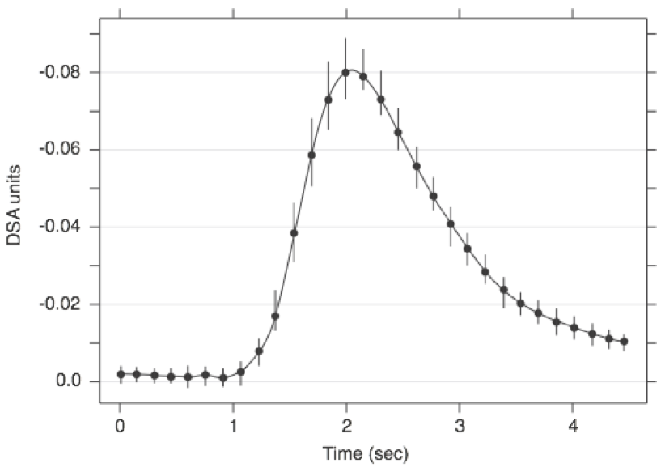

*Credit*: Angela Zoss and Eric Monson, Duke DVS

## Ordering matters

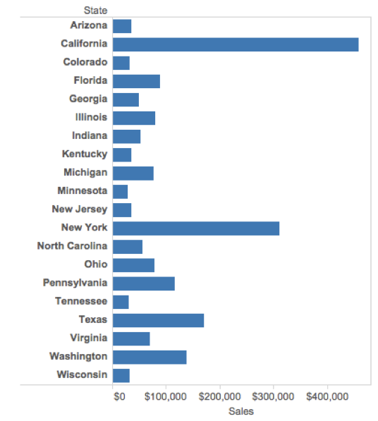

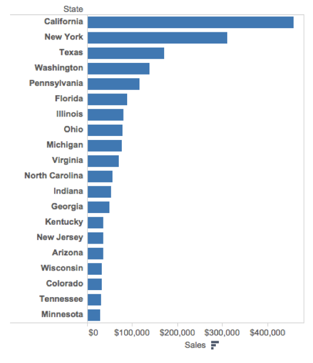

*Credit*: Angela Zoss and Eric Monson, Duke DVS

## Clearly indicate missing data

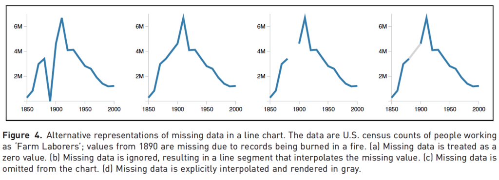

http://ivi.sagepub.com/content/10/4/271, Angela Zoss and Eric Monson, Duke DVS

## Reduce cognitive load

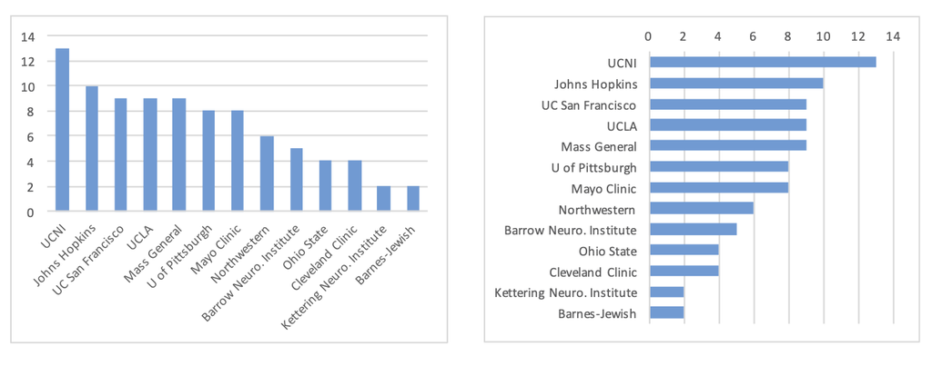

http://www.storytellingwithdata.com/2012/09/some-finer-points-of-data-visualization.html

## Use descriptive titles

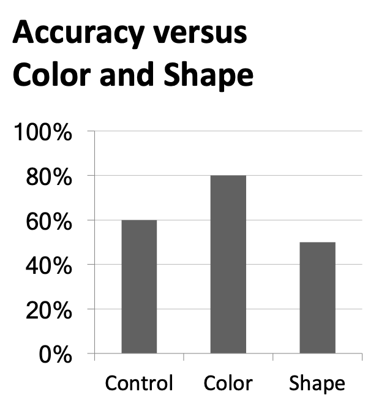

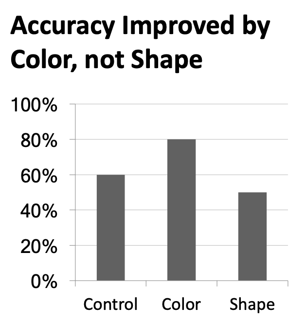

*Credit*: Angela Zoss and Eric Monson, Duke DVS

## Annotate figures

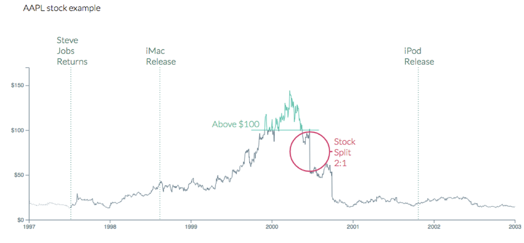

https://bl.ocks.org/susielu/23dc3082669ee026c552b85081d90976

## All of the data doesn’t tell a story

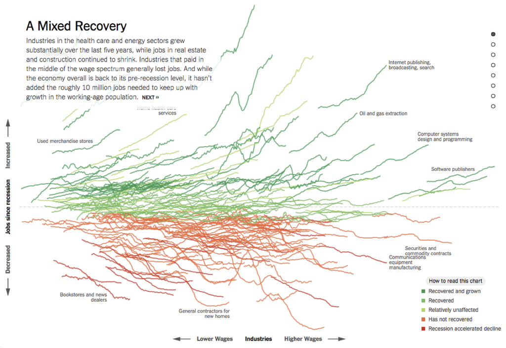

nytimes.com/interactive/2014/06/05/upshot/how-the-recession-reshaped-the-economy-in-255-charts.html

## All of the data doesn’t tell a story

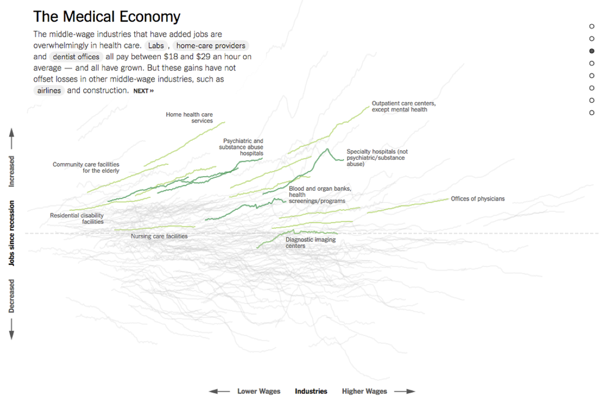

nytimes.com/interactive/2014/06/05/upshot/how-the-recession-reshaped-the-economy-in-255-charts.html

## All of the data doesn’t tell a story

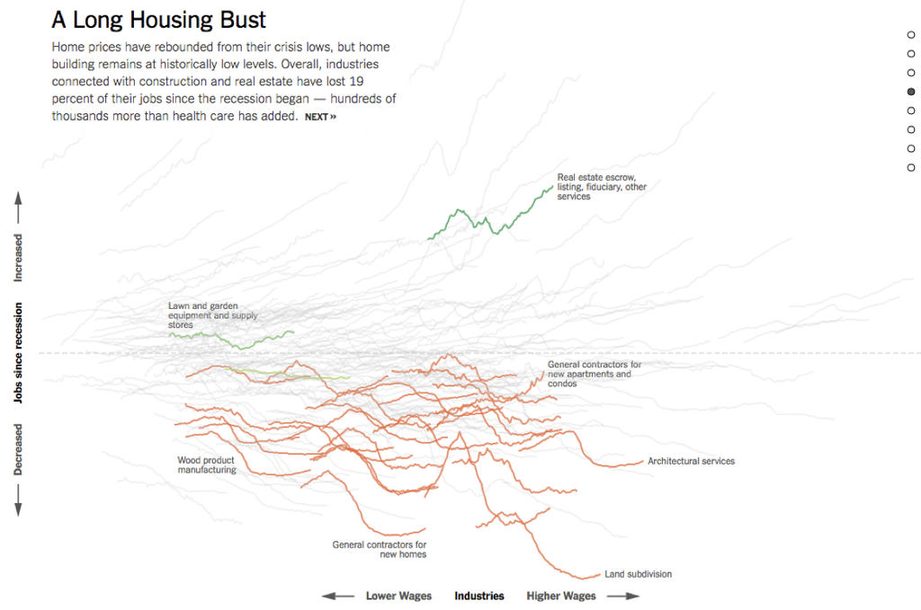

nytimes.com/interactive/2014/06/05/upshot/how-the-recession-reshaped-the-economy-in-255-charts.html

# Chart Remakes / Makeovers

## The Why Axis - Gender Gap

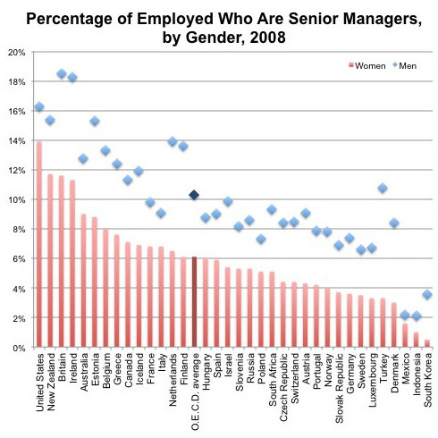

thewhyaxis.info/gap-remake/

## The Why Axis - BLS

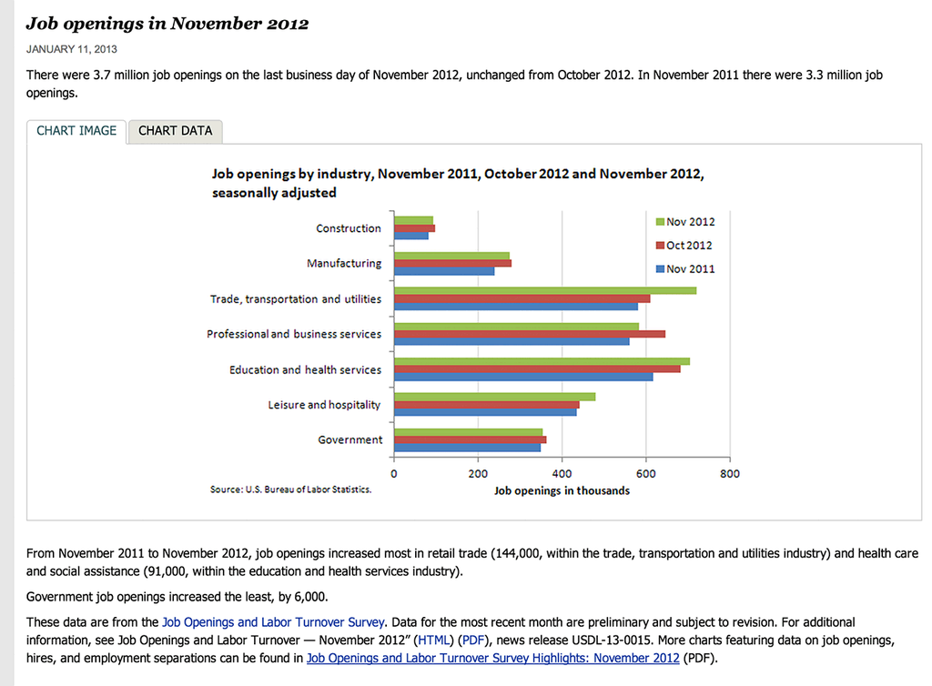

thewhyaxis.info/defaults/

## Other Resources

- Duke Library - Center for Data and Visualization Sciences - https://library.duke.edu/data/
- Tidy Tuesday - https://github.com/rfordatascience/tidytuesday
- Twitter / Bluesky / Mastodon - #dataviz, #tidytuesday
- Books:
  - Wickham, Navarro, Pedersen. *ggplot2: Elegant Graphics for Data Analysis*. 3rd edition. Faller, 2021.
  - Wilke. *Fundamentals of Data Visualization*. O’Reilly Media, 2019.
  - Healy. *Data Visualization: A Practical Introduction*. Princeton University Press, 2018.
  - Tufte. *The visual display of quantitative information*. 2nd edition. Connecticut Graphics Press, 2015.

## Acknowledgments

Above materials are derived in part from the following sources:

- Visualization training materials originally developed by Angela Zoss and Eric Monson
- [Duke Center for Data and Visualization Sciences](https://library.duke.edu/data)